# II ENDHAS

2025-11-12

```
## ℹ tmap modes "plot" - "view"
## ℹ toggle with `tmap::ttm()`
## Modo interativo do tmap ativado: tmap_mode('view')
```

```
## Carregando namespace exigido: GPArotation
```

```
##
##  One Sample t-test
##
## data:  df$su_dif
## t = 1.6244, df = 49, p-value = 0.1107
## alternative hypothesis: true mean is not equal to 0
## 95 percent confidence interval:
##  -0.005240489  0.049440489
## sample estimates:
## mean of x
##    0.0221
```

O estudo contempla duas dimensões centrais, a Universalidade (dimensão social) e a Sustentabilidade (dimensão econômica). A Universalidade se refere ao alcance do atendimento à população, tanto por soluções coletivas quanto individuais. Envolve avaliar: quanto do território municipal é coberto por redes de abastecimento, a proporção da população atendida, as perdas e a continuidade de prestação, a qualidade da água distribuída e indicadores de acesso urbano e total. Essa dimensão busca corresponder à pergunta: “O serviço chega a todos de forma adequada?” Já a Sustentabilidade busca identificar condicionantes da eficiência e capacidade econômico-financeira do prestador, considerando produtividade operacional, relação entre custos, tarifas e receita, suficiência de caixa, perdas na distribuição, consumo energético, despesas operacionais. Aqui a pergunta central é: “O serviço é economicamente consistente para se manter e expandir?”

A análise descritiva tem como objetivo caracterizar o cenário dos serviços de abastecimento de água e esgotamento sanitário nos municípios da Bacia de Furnas, comparar desempenho social e econômico por meio dos scores de Universalidade e Sustentabilidade, Avaliar padrões, desigualdades e tendências, identificando municípios com melhor e pior desempenho,e comparar diferentes periodos para analisar a evolução ao longo do tempo.

O ano de 2021 foi o ano escolhido pois é o ano mais recente cujo o snis esta completo e apto para analise, 2016 foi escolhido para ter um gap interessante entre os diferentes anos.

## Mapas interativos

```
## ── tmap v3 code detected ───────────────────────────────────────────────────────
```

[output not shown]

[interactive chart not shown]

```
## ── tmap v3 code detected ───────────────────────────────────────────────────────
```

[output not shown]

[interactive chart not shown]

```
## ── tmap v3 code detected ───────────────────────────────────────────────────────
```

[output not shown]

[interactive chart not shown]

As FIGURAS 1 e 2 apresentam os mapas dos scores médios (Sustentabilidade + Universalidade) para os anos de 2016 e 2021, respectivamente, com escala de cores que varia do vermelho (piores resultados) ao azul (melhores resultados). A comparação visual entre ambos revela alterações importantes na distribuição espacial do desempenho entre os municípios, as quais serão detalhadas com o apoio das tabelas e sintetizadas no Mapa das Diferenças (FIGURA 3).

De modo geral, observa-se que a evolução dos municípios foi relativamente homogênea, com a maior parte das variações concentrada entre –0,10 e +0,10. Apenas poucos municípios apresentam ganhos ou perdas mais expressivos, o que sugere que, apesar das diferenças encontradas, o padrão regional não passou por transformações profundas no período. Ainda assim, mesmo variações pequenas podem refletir diferenças estruturais entre prestadores, dinâmicas regionais específicas e condições locais de operação que influenciam o desempenho dos serviços de saneamento.

Por fim, essas evidências reforçam a necessidade de análises complementares, especialmente por tipo de prestador, por dimensão (Universalidade e Sustentabilidade) e por indicadores específicos disponíveis na base.

## Tabelas

```
## $Melhores
## # A tibble: 10 × 5
##    Município   Score_Médio Sustentabilidade Universalidade Natureza_Jurídica
##    <chr>             <dbl>            <dbl>          <dbl> <fct>
##  1 Campo Belo        0.943            0.922          0.963 Autarquia
##  2 Nepomuceno        0.928            0.902          0.953 Autarquia
##  3 Varginha          0.883            0.833          0.932 Sociedade de economi…
##  4 Alfenas           0.83             0.763          0.898 Sociedade de economi…
##  5 Lavras            0.821            0.725          0.917 Sociedade de economi…
##  6 Machado           0.82             0.724          0.916 Autarquia
##  7 Três Pontas       0.809            0.666          0.952 Autarquia
##  8 Formiga           0.793            0.633          0.952 Autarquia
##  9 Guaxupé           0.785            0.661          0.909 Sociedade de economi…
## 10 Coqueiral         0.744            0.517          0.971 Autarquia
##
## $Piores
## # A tibble: 10 × 5
##    Município       Score_Médio Sustentabilidade Universalidade Natureza_Jurídica
##    <chr>                 <dbl>            <dbl>          <dbl> <fct>
##  1 Juruaia               0.293            0.453          0.132 Sociedade de eco…
##  2 Nova Resende          0.326            0.484          0.169 Sociedade de eco…
##  3 Conceição da A…       0.335            0.459          0.21  Sociedade de eco…
##  4 Monte Belo            0.344            0.469          0.22  Sociedade de eco…
##  5 Alterosa              0.351            0.384          0.317 Sociedade de eco…
##  6 Vargem Bonita         0.382            0.606          0.157 Sociedade de eco…
##  7 Candeias              0.384            0.48           0.288 Sociedade de eco…
##  8 Campestre             0.386            0.6            0.171 Sociedade de eco…
##  9 Cana Verde            0.401            0.529          0.273 Sociedade de eco…
## 10 Poço Fundo            0.404            0.656          0.152 Sociedade de eco…
```

```
## $Melhores
## # A tibble: 10 × 5
##    Município     Score_Médio Sustentabilidade Universalidade Natureza_Jurídica
##    <chr>               <dbl>            <dbl>          <dbl> <fct>
##  1 Varginha            0.909            0.875          0.943 Sociedade de econo…
##  2 Campo Belo          0.885            0.793          0.976 Autarquia
##  3 Lavras              0.867            0.814          0.92  Sociedade de econo…
##  4 Alfenas             0.866            0.835          0.898 Sociedade de econo…
##  5 Boa Esperança       0.809            0.702          0.915 Autarquia
##  6 Formiga             0.749            0.527          0.971 Autarquia
##  7 Guaxupé             0.748            0.568          0.928 Sociedade de econo…
##  8 Alpinópolis         0.74             0.658          0.822 Sociedade de econo…
##  9 Machado             0.737            0.501          0.974 Autarquia
## 10 Três Pontas         0.733            0.481          0.984 Autarquia
##
## $Piores
## # A tibble: 10 × 5
##    Município       Score_Médio Sustentabilidade Universalidade Natureza_Jurídica
##    <chr>                 <dbl>            <dbl>          <dbl> <fct>
##  1 Alterosa              0.36             0.479          0.241 Sociedade de eco…
##  2 Poço Fundo            0.367            0.574          0.161 Sociedade de eco…
##  3 Candeias              0.382            0.487          0.277 Sociedade de eco…
##  4 Conceição da A…       0.383            0.575          0.192 Sociedade de eco…
##  5 Areado                0.384            0.523          0.244 Sociedade de eco…
##  6 Cana Verde            0.388            0.52           0.256 Sociedade de eco…
##  7 Juruaia               0.393            0.636          0.15  Sociedade de eco…
##  8 Aguanil               0.4              0.014          0.785 Administração pú…
##  9 Campos Gerais         0.416            0.569          0.262 Sociedade de eco…
## 10 Campestre             0.444            0.675          0.213 Sociedade de eco…
```

Em 2016 a tabela com os 10 melhores municipios (FIGURA 4), o topo do ranking é dominado por municípios atendidos por autarquias (Campo Belo, Nepomuceno, Machado, Três Pontas, Formiga), que apresentam desempenho consistente tanto em Sustentabilidade quanto em Universalidade, apesar disso Municípios atendidos por sociedades de economia mista também aparecem bem posicionados (Varginha, Alfenas, Lavras). Alguns destaques são Campo Belo (0.943) lidera, com pontuações quase simétricas entre as dimensões, Nepomuceno (0.928) aparece fortemente em 2016, apesar de cair significativamente até 2021 (como visto no mapa de diferenças). Em 2021 (FIGURA 6),Muitos dos municípios que já estavam entre os melhores em 2016 continuam no topo em 2021, indicando serviços sólidos e bem estruturados. Varginha (0.909) assume a liderança,Campo Belo (0.885) permanece entre os melhores e Lavras, Alfenas e Guaxupé também mantêm posições de destaque. Além disso, As sociedades de economia mista tendem a apresentar pontuações mais equilibradas entre as dimensões e as autarquias se destacam especialmente em Universalidade (vários com >0.95), mostrando maior abrangência no atendimento. Agora, Os 10 piores scores de 2016 (FIGURA 5) concentram-se exclusivamente em municípios atendidos por sociedades de economia mista, com baixos valores sobretudo em Universalidade, Juruaia (0.293) e Nova Resende (0.326) apresentam scores muito baixos, puxados por universalidade reduzida.Outras cidades como Alterosa, Monte Belo, Conceição da Aparecida mostram dificuldades tanto na dimensão econômica quanto no alcance do serviço. Ainda em 2021, (FIGURA 7) vários municípios COMO, Alterosa, Poço Fundo, Candeias, Conceição da Aparecida, Campestre continuam entre os piores nos dois anos mostrando ausência de evolução significativa. A grande exceção é Aguanil, cujo score baixo é causado por Sustentabilidade extremamente reduzida (0.014), apesar de ter Universalidade alta (0.785). Isso indica forte fragilidade econômica e de financiamento do serviço. A maioria dos piores permanece sendo de prestadores classificados como sociedade de economia mista.

Há indícios de que o modelo de gestão pode influenciar o resultado, afinal os melhores desempenhos foram de Autarquias com excelente performance em Universalidade e Sociedades de economia mista com equilíbrio estável entre as dimensões.

E os piores desempenhos tem Predominância quase absoluta de Sociedades de economia mista, especialmente aquelas com baixa Universalidade. Entretanto, o fato de os extremos (melhores e piores) serem dominados sempre pelos mesmos tipos de prestador não é suficiente para conclusões causais, mas indica a necessidade de uma análise específica por modelo de gestão

```
## [1] "--- Top 10 por Score de Universalidade ---"
```

```
## # A tibble: 10 × 3
##    município     `score universalidade` prestador2
##    <chr>                          <dbl> <fct>
##  1 Três Pontas                    0.984 Autarquia
##  2 Guapé                          0.982 Autarquia
##  3 Nepomuceno                     0.982 Autarquia
##  4 Campo Belo                     0.976 Autarquia
##  5 Machado                        0.974 Autarquia
##  6 Formiga                        0.971 Autarquia
##  7 Campo do Meio                  0.955 Autarquia
##  8 Varginha                       0.943 COPASA
##  9 Pimenta                        0.933 Autarquia
## 10 Guaxupé                        0.928 COPASA
```

```
## [1] "--- Top 10 por Score de Sustentabilidade ---"
```

```
## # A tibble: 10 × 3
##    município         `score sustentabilidade` prestador2
##    <chr>                                <dbl> <fct>
##  1 Varginha                             0.875 COPASA
##  2 Capitólio                            0.847 COPASA
##  3 Alfenas                              0.835 COPASA
##  4 São José da Barra                    0.821 COPASA
##  5 Lavras                               0.814 COPASA
##  6 Campo Belo                           0.793 Autarquia
##  7 Camacho                              0.723 COPASA
##  8 Muzambinho                           0.719 COPASA
##  9 Boa Esperança                        0.702 Autarquia
## 10 Vargem Bonita                        0.700 COPASA
```

Para analisar separadamente o efeito de cada uma das dimensões, o ranking com os 10 melhores municípios em 2021 foi construído individualmente para Sustentabilidade e Universalidade.

Nos resultados de Universalidade, observa-se um padrão bastante homogêneo: as autarquias dominam amplamente o topo do ranking, todas apresentando valores superiores a 0,93. Apenas Varginha e Guaxupé, atendidas pela COPASA, aparecem entre os dez melhores, também com níveis elevados de atendimento.

De forma geral, Universalidade apresenta menor variação entre os melhores — quase todos muito próximos de 1 — enquanto Sustentabilidade é a dimensão que mais diferencia os municípios, por refletir custos, produtividade e eficiência operacional.

Além disso, ao comparar esses rankings individuais com o ranking do score médio geral, nota-se que 5 dos 10 melhores municípios em Sustentabilidade também aparecem entre os melhores no score médio. Para Universalidade, esse número é ainda maior, com 6 dos 10 municípios figurando no ranking geral.

Por fim, apenas duas cidades aparecem em comum nos três rankings — Campo Belo e Varginha — justamente aquelas que ocupam as melhores posições no ranking geral, reforçando sua consistência de desempenho nas diferentes dimensões avaliadas.

# Boxplots

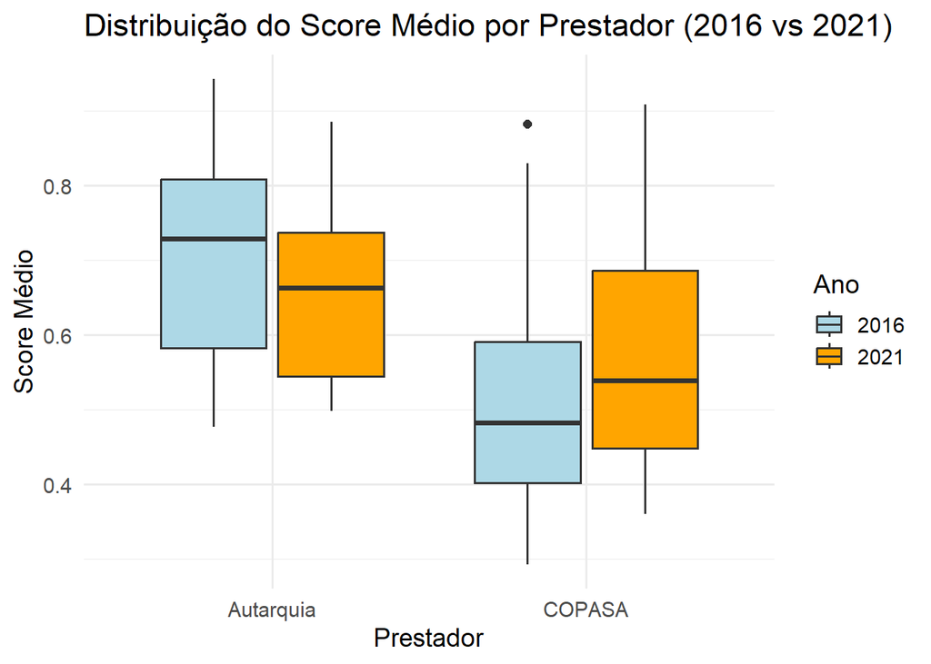

```
##
##       Autarquia         COPANOR          COPASA Empresa privada      Prefeitura
##              13               0              35               1               1
```

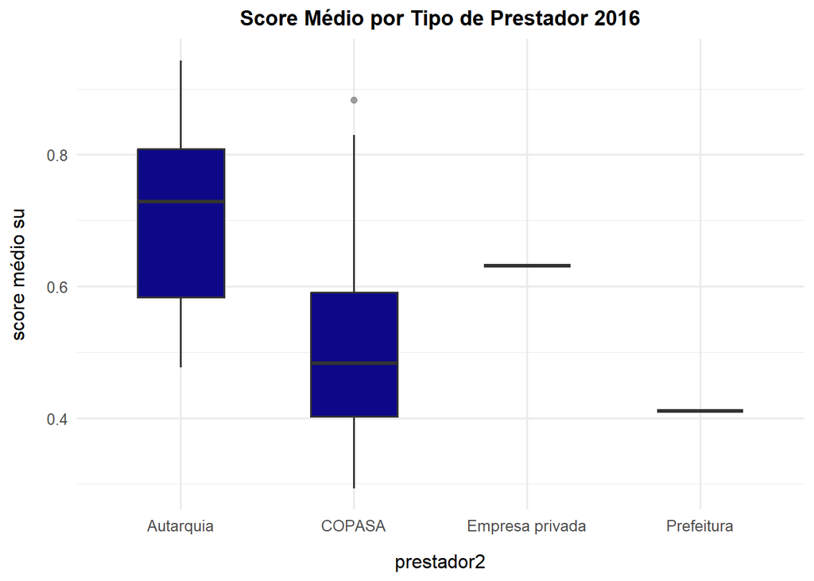

```
##
##       Autarquia         COPANOR          COPASA Empresa privada      Prefeitura
##              13               0              35               1               1
```

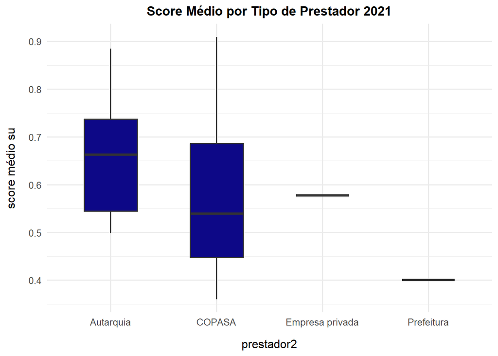

A análise dos boxplots do score médio por tipo de prestador mostra padrões distintos entre 2016 e 2021, tanto na posição das medianas quanto na dispersão das distribuições.

As Autarquias se mantêm como o prestador com melhor desempenho nos dois anos analisados. Em 2016, apresentavam a maior mediana (pouco acima de 0,7) e uma variabilidade moderada. Em 2021, ocorre uma leve redução da mediana para cerca de 0,65, mas o grupo continua ocupando o melhor desempenho geral. A consistência é reforçada pelo tamanho estável da amostra (13 municípios em ambos os anos).

A COPASA apresenta uma pequena elevação na mediana, passando de aproximadamente 0,50 em 2016 para cerca de 0,55 em 2021. Entretanto, sua distribuição se torna significativamente mais ampla, indicando forte heterogeneidade: alguns municípios atingem valores elevados enquanto outros permanecem muito baixos. Essa maior dispersão é compatível com o número elevado de municípios atendidos (35 em cada ano).

Por fim, Empresa Privada e Prefeitura aparecem com apenas um município cada por ano, o que resulta em valores estáveis e representados por linhas nos boxplots. Entre eles, o município atendido pela Prefeitura apresenta a pior mediana em ambos os anos, embora a interpretação seja limitada pelo tamanho mínimo da amostra.

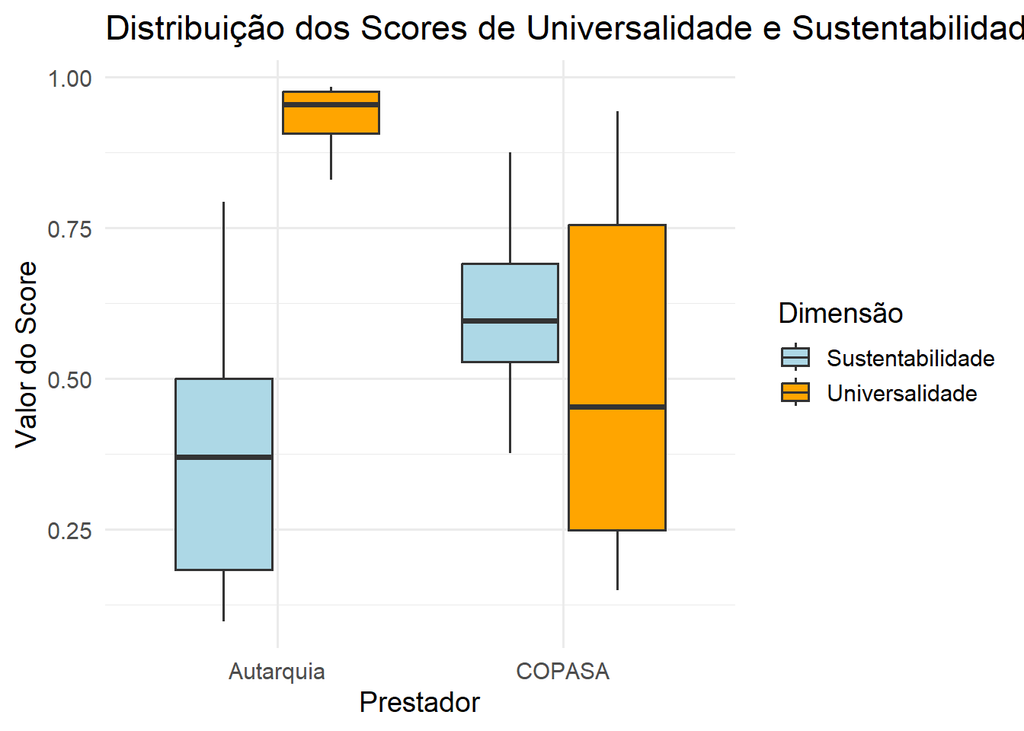

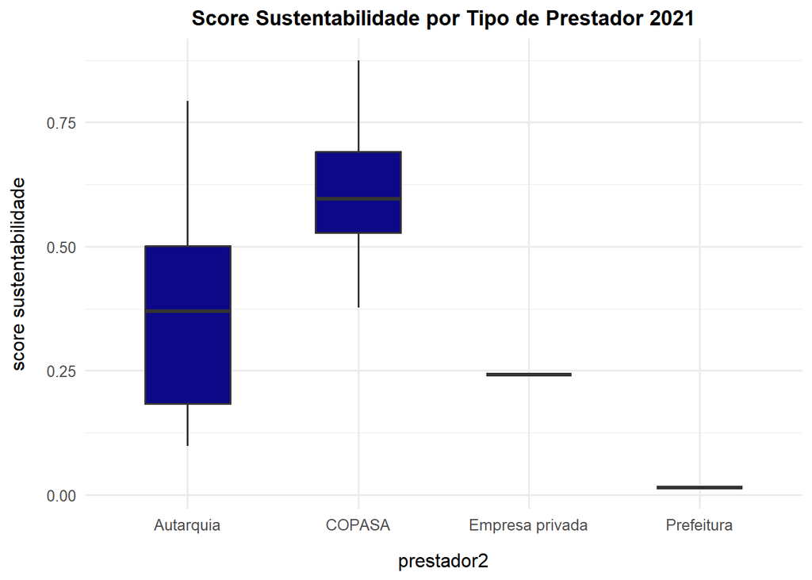

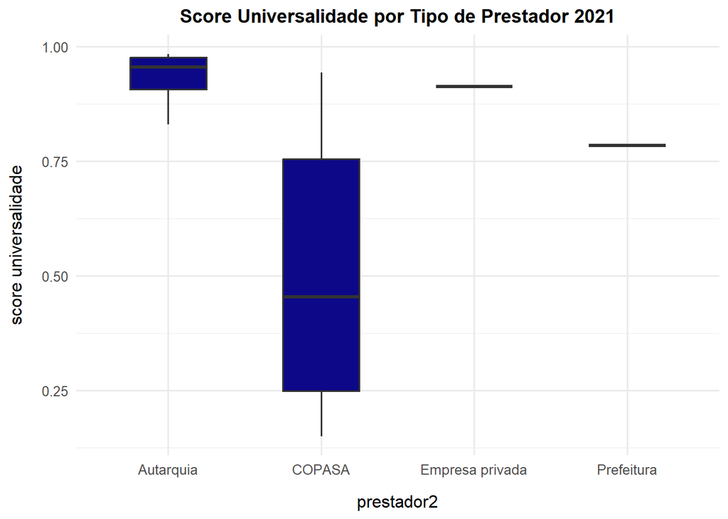

A separação entre Sustentabilidade e Universalidade revela padrões completamente distintos entre os prestadores, reforçando que a dimensão econômica e a dimensão social do saneamento não se comportam da mesma forma.

Na dimensão Sustentabilidade (econômica e operacional), em 2021, a COPASA apresenta o melhor desempenho, com mediana próxima de 0,60, a mais alta entre os prestadores, além de uma caixa relativamente curta, indicando resultados mais homogêneos. Na sequência aparecem as Autarquias, com mediana em torno de 0,38, seguidas pela Empresa Privada, com mediana próxima de 0,25, e pela Prefeitura, com desempenho bastante reduzido, próximo de zero. Esse padrão sugere que a COPASA, como prestador estadual, possui maior robustez financeira e operacional, enquanto a gestão municipal direta tende a apresentar resultados inferiores.

Esses resultados mostram que os prestadores com melhor desempenho social não são os mesmos que apresentam melhor desempenho econômico: Autarquias lideram em universalização, enquanto a COPASA lidera em eficiência operacional.

Por fim, é importante ressaltar que Prefeitura e Empresa Privada aparecem representadas por apenas um município cada, o que limita a interpretação estatística desses dois grupos.

# Histogramas / Densidade

## Universalidade

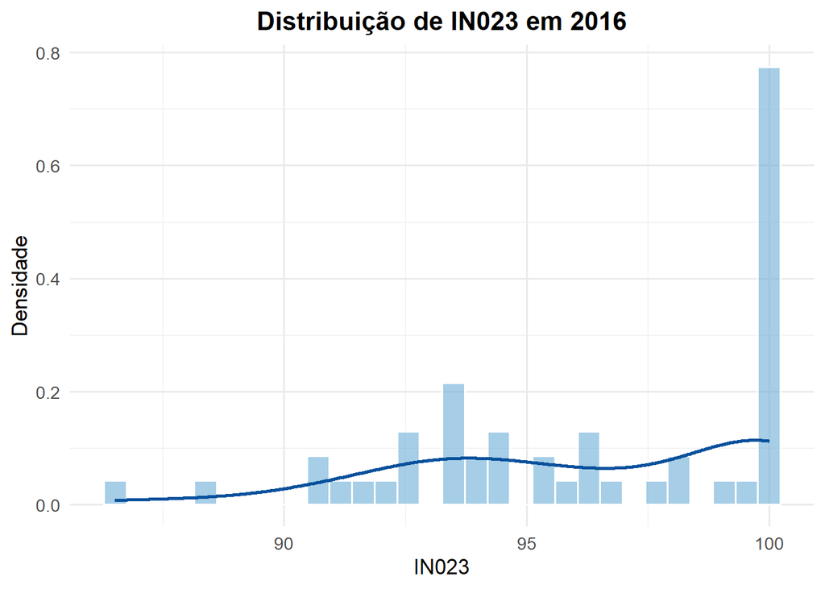

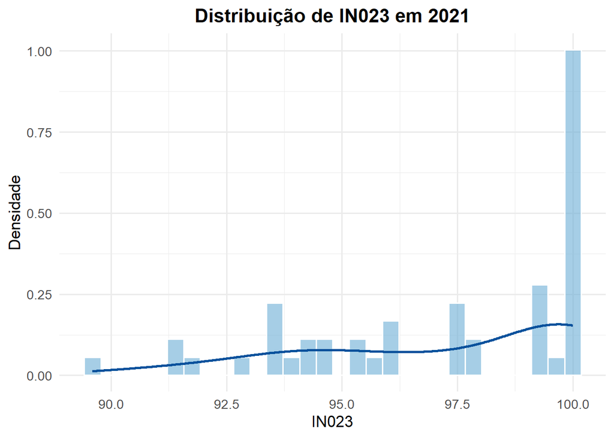

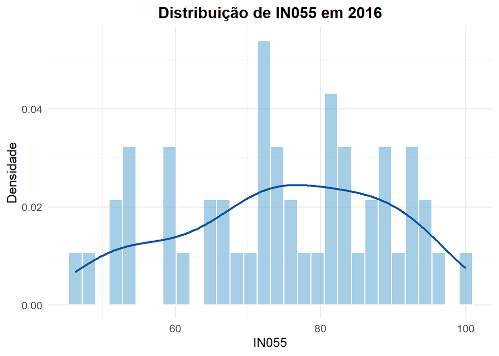

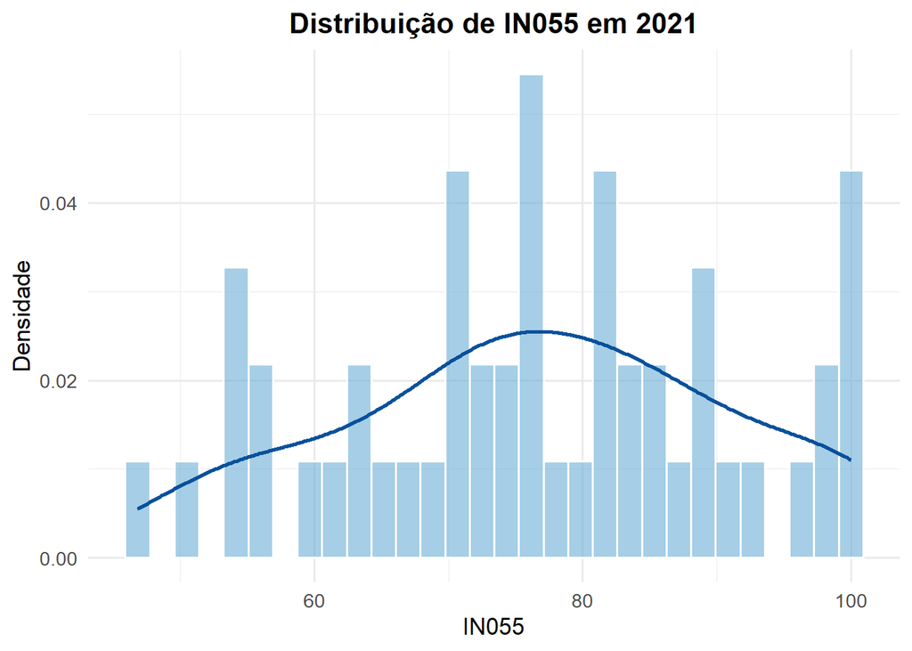

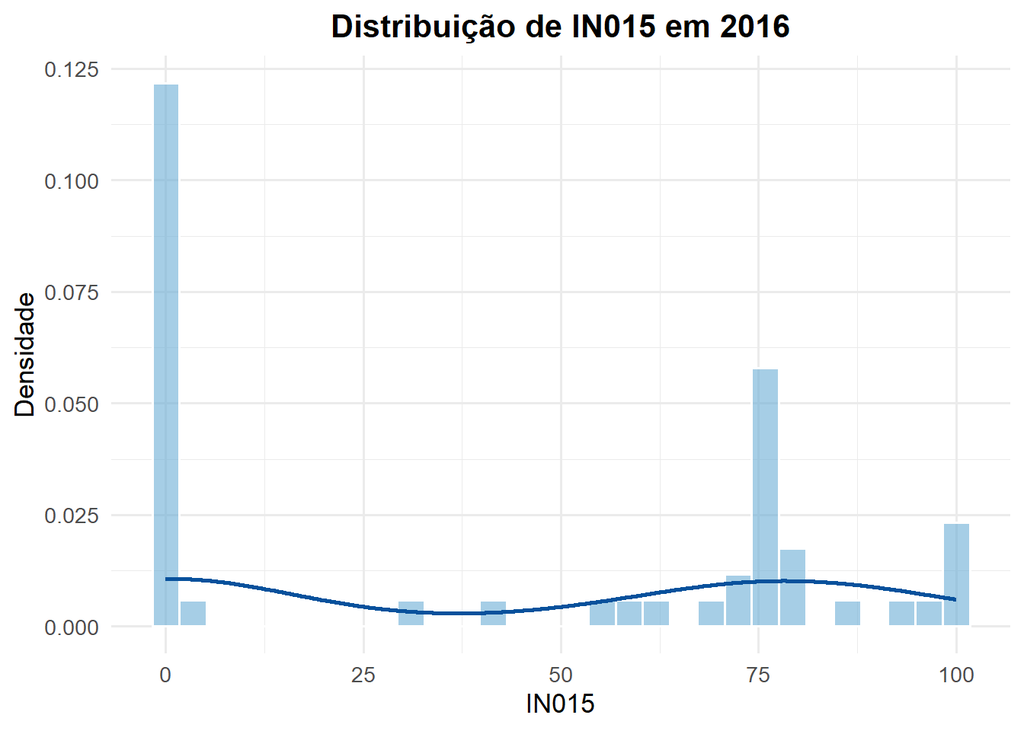

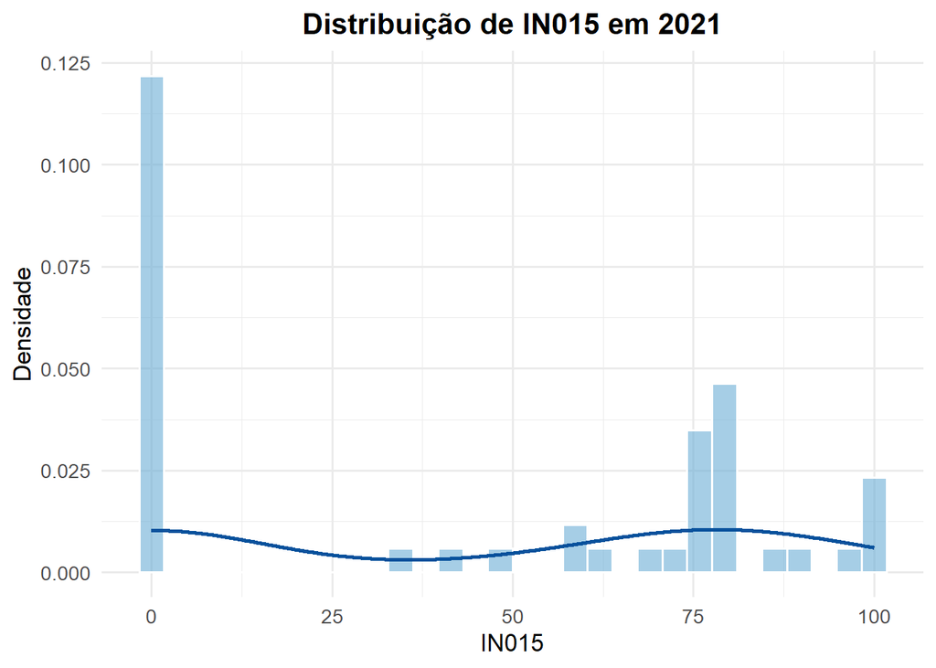

## Sustentabilidade

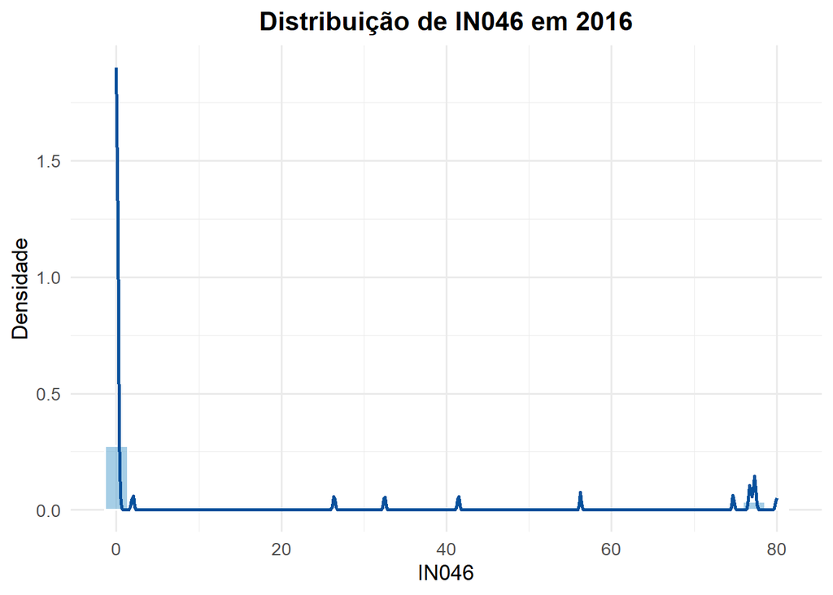

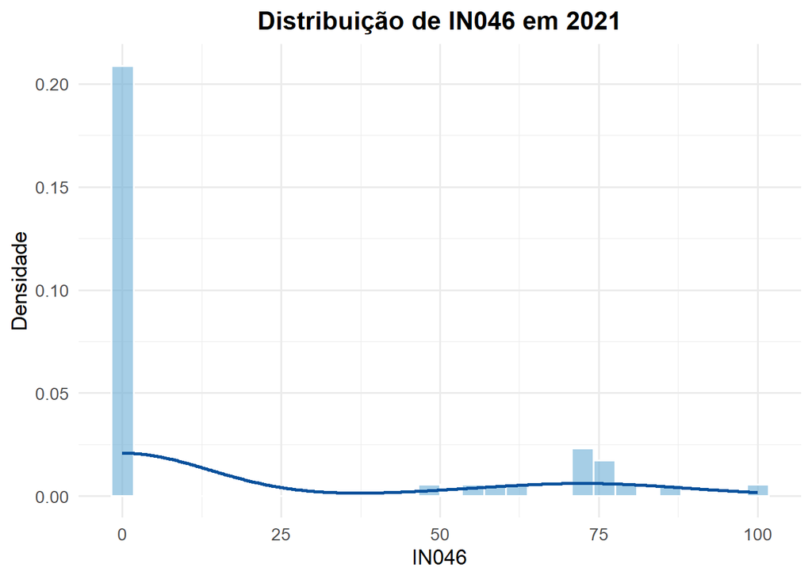

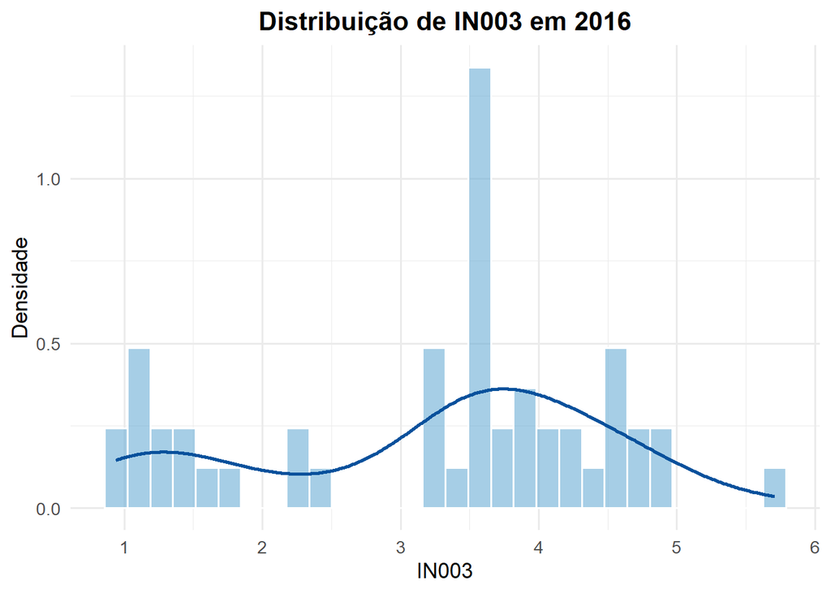

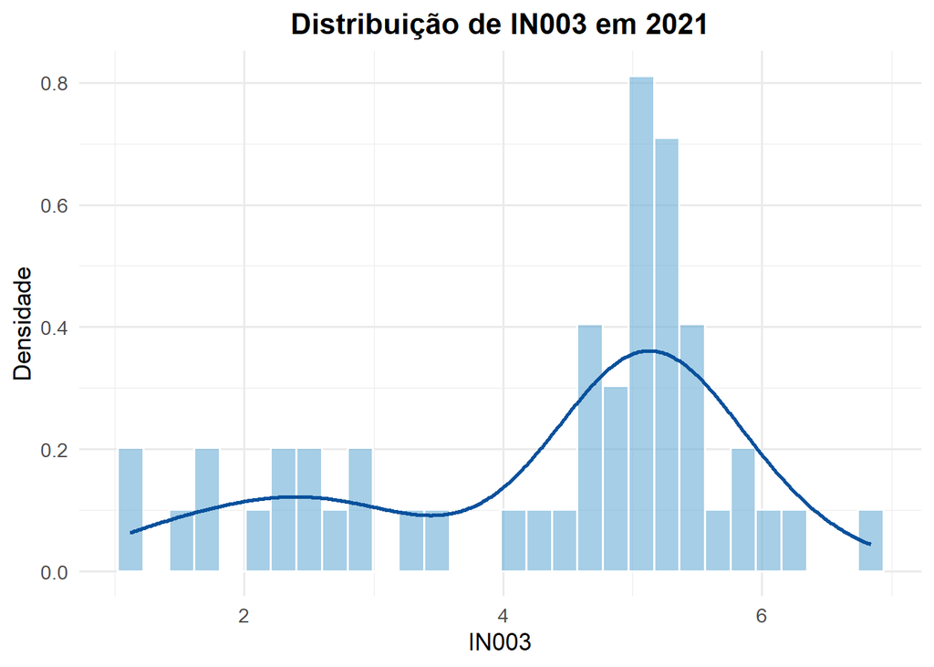